# 9041 Assignment 4

- Show All Code
- Hide All Code
- View Source

Author

Timothy Pong

Published

November 13, 2026

## **Load Dataset**

### Descriptives for Continuous Variable(s) - Age

| variable | mean | sd | min | max |
| --- | --- | --- | --- | --- |
| Age | 29.70 | 14.53 | 0.42 | 80.00 |

### Descriptives for Categorical Variables - Survived, Sex, Pclass

| Survived | n |
| --- | --- |
| 0 | 424 |
| 1 | 290 |

| Sex | n |
| --- | --- |
| female | 261 |
| male | 453 |

| Pclass.Char | n |
| --- | --- |
| First Class | 186 |
| Second Class | 173 |
| Third Class | 355 |

### Predictions

I expect more women to survive compared to men due to emergency precautions in 1912 likely prioritizing women and children more for lifeboats than men who may be expected to sacrifice themselves for the betterment of society and future generations. Ticket class also likely influenced access to emergency equipment and precautions where higher classes may have priority access to lifesaving measures. However, the opposite could be true where lower class passengers might have also been situated on lower decks that were closer to lifeboats. Finally, young children and older adults and seniors may have had a higher mortality rate than adolescents and adults.

## Fitting Nested Models

While every model and its predictors are all significant, AIC and BIC noticeably decrease between models as predictors as added, suggesting unique and substantial portions of variability are explained with each new predictor. While estimates for predictors relatively stable with the inclusion of newer predictors, the estimate for the intercept increases between models. Seemingly, being male, or being a second or third class passenger was associated with lower likelihood of survival. Additionally, younger passengers appear to have had a higher rate of survival, though the estimate for age is considerably lower than those of other variables.

## Comapring Model Performance

|  | Nested.Chisq.stat | Nested.df | Nested.p.value |
| --- | --- | --- | --- |
| mod_int | NA | NA | NA |
| mod_sex | 213.81576 | 1 | 2.020274e-48 |
| mod_sex_class | 78.26950 | 2 | 1.009241e-17 |
| mod_sex_class_age | 25.14758 | 1 | 5.310615e-07 |

### Extract Nested Model-Level Performance Statistics

| Model | AIC | BIC | Log-likelihood | Deviance | Residual.df | Nested df | Nested χ² | Nested p |
| --- | --- | --- | --- | --- | --- | --- | --- | --- |
| mod0: Null | 966.516 | 971.087 | −482.258 | 964.516 | 713 | — | — | — |
| mod1: Sex | 754.700 | 763.842 | −375.350 | 750.700 | 712 | 1 | 213.816 | < .001 |
| mod2: + Class | 680.431 | 698.714 | −336.215 | 672.431 | 710 | 2 | 78.269 | < .001 |
| mod3: + Age | 657.283 | 680.138 | −323.642 | 647.283 | 709 | 1 | 25.148 | < .001 |

## Evaluating Binary Logistic Regression Diagnostics

### Examining Assumptions

#### Linearity

```r
set.seed(10000)
res_mod3 <- simulateResiduals(mod_sex_class_age, n = 500, plot = FALSE)
```

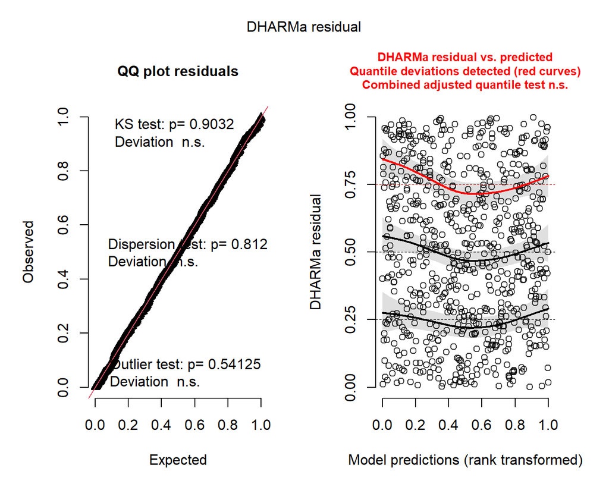

Linearity appears to be fine based on teh Q-Q plot and associated tests.

#### Collinearity

| Term | VIF | VIF_CI_low | VIF_CI_high | SE_factor | Tolerance | Tolerance_CI_low | Tolerance_CI_high |
| --- | --- | --- | --- | --- | --- | --- | --- |
| Sex | 1.072868 | 1.023276 | 1.228121 | 1.035794 | 0.9320808 | 0.8142521 | 0.9772532 |
| Pclass.Char | 1.416520 | 1.302631 | 1.573268 | 1.190176 | 0.7059556 | 0.6356198 | 0.7676769 |
| Age | 1.333062 | 1.231654 | 1.478861 | 1.154583 | 0.7501529 | 0.6761960 | 0.8119165 |

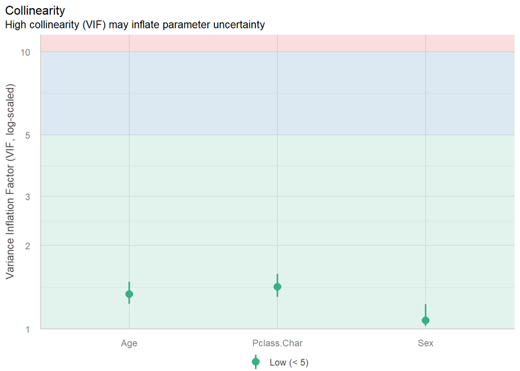

Collinearity based on both tests and plots appear to be normal.

#### Complete Separation

Coefficients and standard errors are within reason. There were no warnings from glmmTMB about convergence. Fitted probabilities are not essentially 0 or 1 for some groups.

#### Influence

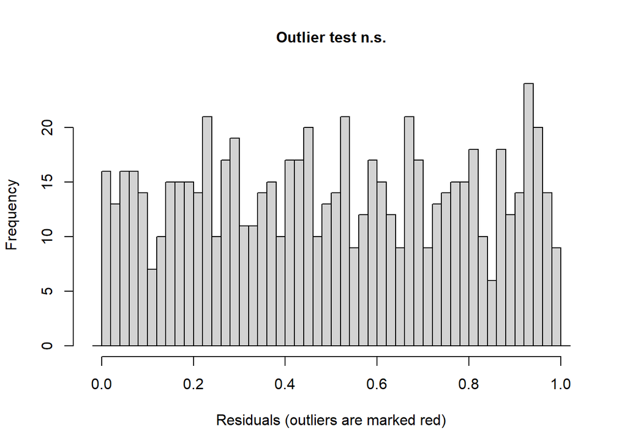

```
    DHARMa outlier test based on exact binomial test with approximate
    expectations

data:  res_mod3
outliers at both margin(s) = 1, observations = 714, p-value = 0.5412
alternative hypothesis: true probability of success is not equal to 0.003992016
95 percent confidence interval:
 3.545849e-05 7.778486e-03
sample estimates:
frequency of outliers (expected: 0.00399201596806387 )
                                            0.00140056
```

No significant outliers

#### Events per predictor

Here we have 290 survived and 424 died, with 5 coefficients in `mod_sex_class_age`.

There are at least 10 events and 10 non-events (i.e., survived vs. not survived) per coefficient.

### Select and Report the Preferred Model

The selected model that I will be reporting is the full model containing all three predictors - sex, class, and age. Nested X^2 test values, AIC, and BIC all indicate substantive improvement in this model compared to simpler models. Furthermore, diagnostic findings do not indicate notable deviation from assumptions. While it is the most complex, it appears to be the nonetheless, the best choice of model for predicting surviving the titanic. All three predictors have clear rationale for being related to titanic survivorship.

| Predictor | Estimate | SE | 95% CI lower | 95% CI upper | p |
| --- | --- | --- | --- | --- | --- |
| (Intercept) | 3.777 | 0.401 | 2.991 | 4.563 | < .001 |
| Sexmale | −2.523 | 0.207 | −2.929 | −2.116 | < .001 |
| Pclass.CharSecond Class | −1.310 | 0.278 | −1.855 | −0.765 | < .001 |
| Pclass.CharThird Class | −2.581 | 0.281 | −3.132 | −2.029 | < .001 |
| Age | −0.037 | 0.008 | −0.052 | −0.022 | < .001 |

#### Interpreting Co-Efficients

```
                              2.5 %     97.5 %    Estimate
(Intercept)             19.90247237 95.8881870 43.68537504
Sexmale                  0.05343656  0.1204762  0.08023611
Pclass.CharSecond Class  0.15648543  0.4654238  0.26987411
Pclass.CharThird Class   0.04362034  0.1314643  0.07572659
Age                      0.94933776  0.9782599  0.96369034
```

Holding class and age constant, identifying as a male was associated with 0.08 times the odds of surviving, 95% CI [0.05, 0.12].

Holding sex and age constant, being a second class passenger is associated with 0.27 times the odds of surviving, 95% CI [0.16, 0.47]; being a third class passenger is associated with 0.08 times the odds of surviving, 95% CI [0.04, 0.13].

Holding sex and class constant, a 1-year increase in age is associated with 0.96 times the odds of surviving, 95% CI [0.95, 0.98].

#### Overall Model Performance

| Model | AIC | BIC | Log-likelihood | Deviance | Residual df | Nested df | Nested χ² | Nested p |
| --- | --- | --- | --- | --- | --- | --- | --- | --- |
| mod3: + Age | 657.28 | 680.14 | −323.64 | 647.28 | 709.00 | 1.00 | 25.15 | 0.00 |

### Results Summarized

> We fit a binomial GLM with a logit link predicting titanic surviorship from sex, ticket class, and age. Being a male was associated with lower odds of surviving, OR = 0.08, 95% CI [0.05, 0.12]. Being a second class passenger was associated with lower odds of surviving, OR = 0.27, 95% CI [0.16, 0.47] Being a third class passenger was associated with lower odds of surviving, OR = 0.08, 95% CI [0.04, 0.13] Being older was associated with lower odds of surviving such that for every one year of age, the odds of surviving was 0.96, 95% CI [0.95, 0.98].

#### Sex

Visualization of sex and survivorship

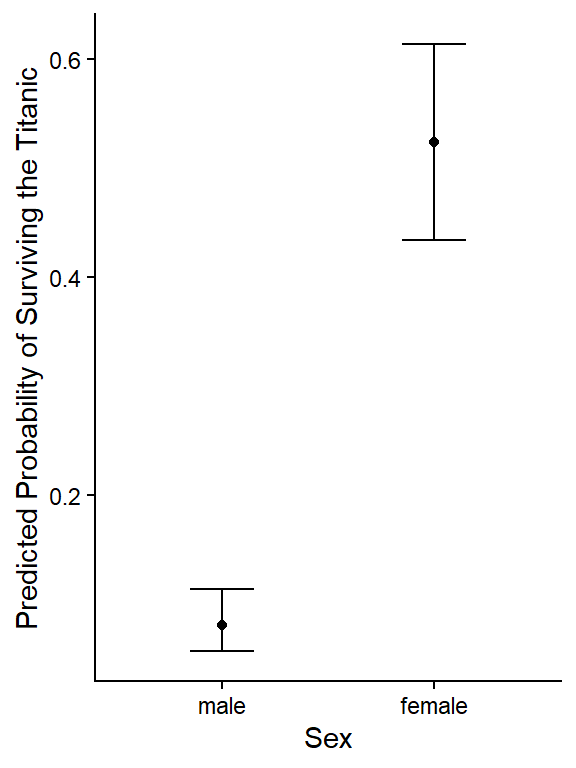

## Findings and Limitations

The findings of the full (and preferred) model match expectations based on what we know of emergency procedures of the time. For instance, men had a drastically lower odds of surviving than women such that men had 0.08 times the odds of surviving. This makes sense since culture and protocol at the time was to prioritize women and children first over men in evacuations. In the same vein, this may also help explain why younger passengers had greater survivorship where every 1 year of a passenger’s age was associated with 0.96 odds of surviving. Thus, this protocol of “women and children” on lifeboats/rafts first may play a large role in answering who survived the titanic since (to my recollection), the rate of survival for those who did not make it onto a raft was nearly none. Furthermore, it is unsurprising that ticket class affected rate of survival. In this case, those of lower ticket classes than first class such as second or third class ticket holders had dramatically lower rates of survival. This would support, though not necessarily confirm the hypothesis that first-class ticket holders had greater odds of survival due to better access to evacuation and emergency protocol and equipment. More hypothetically, since ticket class is likely associated with SES, it is also possible that those of higher education and wealth may have had greater personal knowledge and access to lifesaving measures. Put together, the model comparisons suggest that all three (i.e., sex, class, age) are notable predictors of surviving the Titanic. While there are likely more predictors at play, these three predictors of sex, class, and age very likely play a large part in determining who survives. Nonetheless, it is possible that the interpretation of these predictors in our current models and estimates don’t fully capture their effects and nuances. For example, here, we examine age in a linear fashion, without capturing the nuance of a potential non-linear relationship with survivorship. For instance, it may be possible that infants and children under 10 or 11 may have drastically lower survival rates similar to the elderly. Though in this case, all our model and estimates can capture is that survival decreases as age increases - which could be an inaccurate statement if the relationship is skewed. It would therefore be pertinent to investigate potential nuances with age as a predictor of survival, and also look into potential interactions between sex, class, and other factors.